# Simple Perceptron Implementation

This notebook implements a version of the perceptron as introduced by Frank Rosenblatt's 1958 paper, "The Perceptron: A Probabilistic Model for Information Storage and Organization in the Brain".

We will use the most basic math concepts possible, avoiding linear algebra to the extent possible.

## Objective

The goal is to train a model with two weights, $w_{1},\ w_{2}$, one for each of the coordinates $x,\ y$ of a point defined as $(x,\ y)$, and one bias $b$, using an adaptation of the algebraic equation $y = mx + c$ of the slope-intercept form of a line.

The model will deal with a simple classification task, of a liniar separably dataset based on the following function:

$ f: \mathbb{N} \to \mathbb{N}, \quad f(x) = \begin{cases} x & \text{if } x \bmod 2 = 0, \\ 2x & \text{if } x \bmod 2 = 1. \end{cases} $

## Dataset

First, we will generate a dataset, using the Python Standard Library.

```python
import random

def generate_dataset(num_items=20, start=0, stop=100):
    random.seed(42)
    dataset = []
    x1_values = set()
    while len(dataset) < num_items:
        x1 = random.randint(start, stop)
        if x1 in x1_values:
            continue
        x1_values.add(x1)
        x2 = x1 if x1 % 2 == 0 else 2*x1
        y = 0 if x1 == x2 else 1 # (x1, x2) is labeled as Class 0 if x1 is even, and Class 1 otherwise
        dataset.append((x1, x2, y))
    return dataset

dataset = generate_dataset()

# let's now split the dataset into training and test sets
train_ratio = 0.8
num_train = int(len(dataset) * train_ratio)
dataset_train, dataset_test = dataset[:num_train], dataset[num_train:]
print(f"Training set (n={len(dataset_train)}): {dataset_train}")
print(f"Test set (n={len(dataset_test)}: {dataset_test}")
```

```
Training set (n=16): [(81, 162, 1), (14, 14, 0), (3, 6, 1), (94, 94, 0), (35, 70, 1), (31, 62, 1), (28, 28, 0), (17, 34, 1), (13, 26, 1), (86, 86, 0), (69, 138, 1), (11, 22, 1), (75, 150, 1), (54, 54, 0), (4, 4, 0), (27, 54, 1)]
Test set (n=4: [(29, 58, 1), (64, 64, 0), (77, 154, 1), (71, 142, 1)]
```

## Visual Representation

Using Matplotlib we will visually representt the training and test datasets.

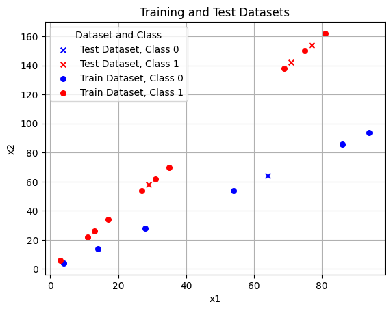

```python
import pandas as pd
import matplotlib.pyplot as plt

def plot_datasets(train_dataset, test_dataset):
    # Combine datasets into a DataFrame for easier handling
    train_df = pd.DataFrame(train_dataset, columns=["x1", "x2", "class"])
    train_df["set"] = "Train"

    test_df = pd.DataFrame(test_dataset, columns=["x1", "x2", "class"])
    test_df["set"] = "Test"

    combined_df = pd.concat([train_df, test_df], ignore_index=True)

    # Define colors and markers
    colors = {0: "blue", 1: "red"}
    markers = {"Train": "o", "Test": "x"}

    # Plot each group using Matplotlib
    fig, ax = plt.subplots()
    for (dataset, cls), group in combined_df.groupby(["set", "class"]):
        ax.scatter(
            group["x1"],
            group["x2"],
            color=colors[cls],
            label=f"{dataset} Dataset, Class {cls}",
            s=30,
            marker=markers[dataset]
        )

    # Manage legend and labels
    handles, labels = ax.get_legend_handles_labels()
    by_label = dict(zip(labels, handles))
    ax.legend(by_label.values(), by_label.keys(), title="Dataset and Class")
    ax.set_xlabel("x1")
    ax.set_ylabel("x2")
    ax.set_title("Training and Test Datasets")
    ax.grid(True)

plot_datasets(dataset_train, dataset_test)
plt.show()
```

## Defining a Linear Classifier

With our dataset prepared, we now turn to the mathematical foundation that enables our model to classify an input $x_{1} \text{and} x_{2}$ as belonging to classes $0$ or $1$, as follows:

This classification can be achieved by using the algebraic representation of a line in a Cartesian coordinate system, described by:

$ z(x) = w_{1}x_{1}+w_{2}x_{2} + c, $

where:

- $w_{1} text{ and } w_{2}$ represent the weights that determine the slope representing the angle of the resulting line relative to the $x$-axis,
- $c$ is the intercept, indicating where the line intersects the $y$-axis.

From the plotted graph above, it becomes clear that the two classes are linearly separable, which makes the use of a linear separation boundary where $w_{1} \text{ and } w_{2}$ are trained using Rosenblatt's Perceptron algorithm appropriate.

To drive this point home, here's how a line defined by $w_{1}=1, w_{2}=0.5, \text{ and } c=0$ would look like plotted on our previous image.

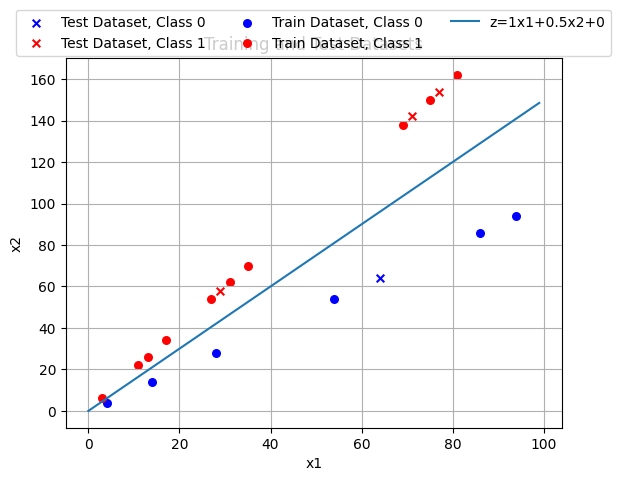

```python
zx = lambda x1,x2,w1,w2,c: w1*x1 + w2*x2 + c

def plot_zx(w1,w2,c):
    plt.plot([zx(x,x, w1, w2, c) for x in range(100)], label=f'z={w1}x1+{w2}x2+{c}')

def plot_datasets_and_zx(w1, w2, c):
    plot_datasets(dataset_train, dataset_test)
    plot_zx(w1, w2, c)
    plt.legend(loc="upper center", bbox_to_anchor=(0.5, 1.15), ncol=3)

plot_datasets_and_zx(1,0.5,0)
```

Now, it is obvious that in this configuration the datapoints are seperated neatly. There are, however, alternative ways to configure $w_{1},\ w_{2}, \text{ and } c$ to achieve less ideal examples. For example, when $w_{1}=0.1,\ w_{2}=0.1, \text{ and } c=0.5$, we gen a less ideal separation boundary.

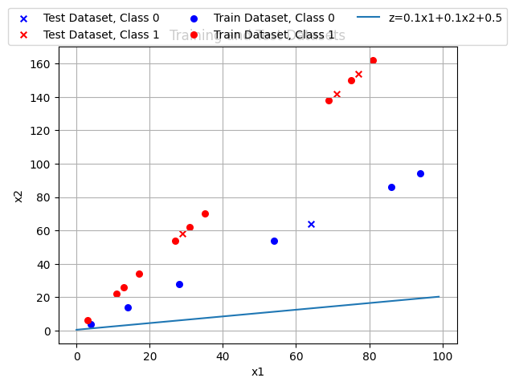

```python
plot_datasets_and_zx(0.1, 0.1, 0.5)
```

## Evaluating the performance of the classifier

### Defining the classifier

But before we delve into the performance of our classifier, let's actually define it as follows:

$ c(x)= \begin{cases} 0 & \text{if } x < f(x), \\ 1 & \text{if } x >= f(x). \end{cases} $

In essence, this means that if a number $x$ is above the decision boundary defined by $f(x)$, it will be classified as $1$, otherwise $0$.

```python
cx = lambda x, m, c: 0 if x < fx(x, m, c) else 1

def accuracy(dataset, m, c):
    correct = 0
    for x, y in dataset:
        if y == cx(x, m, c):
            correct += 1
    return correct / len(dataset)

print(f"Accuracy on training set: {accuracy(dataset_train, 0, 0.5)}")
```

[output not shown]